# Introduction to R for Public Health Researchers

[figure not shown]

## Overview:

**Welcome to Introduction to R for Public Health Researchers!**

This course is for students who have little to no familiarity with the R programming language and want to learn more about how to use R to import, wrangle, visualize, and analyze data.

The course will provide students with **“hands-on” training** for analyzing data with the R programming language for statistical computing, a popular open-source solution for data analysis and visualization.

## Instructors:

- [Carrie Wright](https://carriewright11.github.io/): cwrigh60 at jhu.edu
- [Ava Hoffman](https://www.avahoffman.com/): ava.hoffman at jhu.edu
- [Candace Savonen](https://www.cansavvy.com/): csavone1 at jhu.edu

## TAs

- Grant Schumock - gschumo1 at jhmi.edu
- Qier Meng - qmeng11 at jhmi.edu

## Class:

- Jan 10-21, 2022, 8:30AM-11:50AM on Zoom - No class on Jan 17th for Martin Luther King Jr. Day.
- CoursePlus: https://courseplus.jhu.edu/core/index.cfm/go/syl:syl.public.view/coid/16733/
- Syllabus
- Syllabus (Word Document)

## Zoom:

- Zoom link will be emailed to students
- Class sessions will be recorded and later posted
- We will have lectures as well as breakout room sessions to work on labs
- Please be aware that there is the option to use closed captioning:

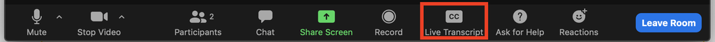

- During lectures you can indicate how you feel about the pace of the course like so:

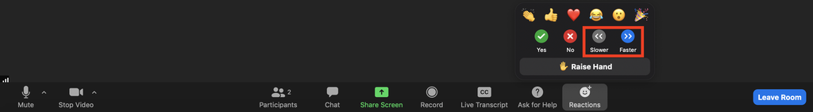

- In breakout room sessions you can ask for help like so:

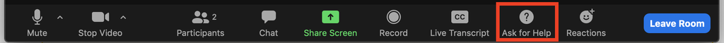

- If you have a question based on our labs or homework (or not covered during lecture time), we ask that you post it on slack (which will be our main communication method - the link will be emailed). This allows for questions to be seen by everyone, not just the students in your breakout room. If another student does not answer your question (which we encourage!), we will try to answer it within 24 hours. If you feel uncomfortable posting a question publicly, let a TA or instructor know your question and we will post it for you anonymously.

## Grading

1. Attendance/Participation: 20% (Please let the instructors know if attendance will be difficult for you.)
2. Homework: 3 x 15%
3. Final “Project”: 35%

All assignments are due Wednesday, Jan 26, 2022 at 11:59pm EST.

**Note**: only people taking the course for credit must turn in the assignments. However, we will evaluate all submitted assignments in case others would like feedback on their work.

## Submitting Assignments

Submit each assignment to the designated [Drop Box on CoursePlus](https://courseplus.jhu.edu/core/index.cfm/go/db:main/coID/16733/).

You should complete the following:

1. [Data Quest: Introduction to Programming in R](https://app.dataquest.io/m/499/introduction-to-programming-in-r)
2. Homework 2 Problem Set:
   - [Questions (Rmd)](https://jhudatascience.org/intro_to_r/HW/homework2.Rmd), [Questions (HTML)](https://jhudatascience.org/intro_to_r/HW/homework2.html)
   - [Key (Rmd)](https://jhudatascience.org/intro_to_r/HW/homework2_key.Rmd), [Key (HTML)](https://jhudatascience.org/intro_to_r/HW/homework2_key.html)
3. Homework 3 Problem Set:
   - [Questions (Rmd)](https://jhudatascience.org/intro_to_r/HW/homework3.Rmd), [Questions (HTML)](https://jhudatascience.org/intro_to_r/HW/homework3.html)
   - [Key (Rmd)](https://jhudatascience.org/intro_to_r/HW/homework3_key.Rmd), [Key (HTML)](https://jhudatascience.org/intro_to_r/HW/homework3_key.html)
4. Final Project (see below)

## Final Projects

This project should entail:

- reading in a dataset of your choosing
- doing some light data cleaning
- performing some data summarization
- creating a couple of visualizations
- doing some very light statistical analysis, like regression or t-tests

You may use one of these public datasets, a different public dataset, or your own data for the project. If using your own dataset, be sure any sensitive information is protected.

- https://www.data.gov/
- https://data.baltimorecity.gov/
- https://github.com/awesomedata/awesome-public-datasets

Example projects can be found with the source code: Rmd, and the output html here.

See the guidelines/instructions for final projects.

## Code of Conduct

We would like to create an open, safe, welcoming, diverse, inclusive, intellectually stimulating, and hopefully fun class experience.

We strive to be a space in which individual differences are respected, so that each individual can reach their fullest potential.

### Guidelines

- Demonstrating empathy and kindness toward other people
- Giving and gracefully accepting constructive feedback
- Avoiding making assumptions about others
- Being respectful of differing opinions, viewpoints, and experiences
- Take the time to consider how your speech and actions may influence others
- Actively seek to acknowledge and respect the boundaries of other members
- Demonstrating academic integrity
  - Students can work together, but assignments must show unique contributions from the student who turns in the assignment
  - Students can use online resources for help, but assignments must show unique contributions from the student who turns in the assignment - plagiarism is not allowed
  - If students are struggling, reach out to instructors or TAs as early as possible

This applies to emails, surveys, Slack, Zoom, office hours, meetings with other students, instructors, or TAs.

**Please reach out to a TA or instructor if you witness or experience a violation of the class guidelines or other JHU codes of conduct.**

- **JHU Student Code of Conduct:**  
  https://studentaffairs.jhu.edu/policies-guidelines/student-code/
- **Hopkins School of Medicine:**  
  https://www.hopkinsmedicine.org/research/resources/offices-policies/OPC/Research_Integrity/som_code_of_conduct_04302020.pdf
- **JHSPH Academic Ethics Code:**  
  https://www.jhsph.edu/offices-and-services/student-affairs/resources/student-policies/_documents/academic-ethics-code.pdf

**The University has developed avenues for reporting and for seeking help including:**

● JHU Sexual Assault Helpline, 410-516-7333 (confidential) ● Campus Safety and Security, 410-516-7777 ● University Sexual Assault Response and Prevention website ● Johns Hopkins Compliance Hotline, 844-SPEAK2US (844-733-2528) ● JHU Office of Institutional Equity 410-516-8075 (nonconfidential) ● Johns Hopkins Student Assistance Program (JHSAP), 443-287-7000 ● University Health Services - Mental Health (UHS-MS), 410-955-1892 ● The Faculty and Staff Assistance Program (FASAP), 443-997-7000

## All the Requirements in this Course

#### Packages

We have an `R` package called `jhur` that will make sure all the packages are installed.

```r
install.packages("remotes")
remotes::install_github("muschellij2/jhur")
```

#### Data

All the data used that are not **specifically** to be downloaded from the web are located in this zip file, but we will show you how to read data from the internet as well.

## Schedule

In recognition of [Martin Luther King Jr. Day](https://en.wikipedia.org/wiki/Martin_Luther_King_Jr._Day), there will be no class on Monday January 17th 2022. There is an assignment due before class to [install software](https://courseplus.jhu.edu/fileDepot/onlineLibrary/1280/R_and_RStudio_installation.html) and we recommend completing HW 1 (uploading a screenshot showing that you finished the Dataquest module indicated below) before class, but all other assignments will be due January 26th. You are welcome to turn assignments in earlier if you wish.

| **Day** | **Module** | **Slides** | **Code** | **Resource** | **Cheatsheets/Guides** |
| --- | --- | --- | --- | --- | --- |
| Day 0 | Homework 1 |  | [Dataquest](https://app.dataquest.io/login?target-url=%2Fm%2F499%2Fintroduction-to-programming-in-r) |  |  |
| Day 1 | Intro | HTML, PDF | R, Rmd |  | [Day 1 Cheatsheet](https://github.com/jhudsl/intro_to_r/blob/main/cheatsheets/Day-1.pdf) |
|  | RStudio | HTML, PDF | R, Rmd | Lab, Key, Key HTML |  |
|  | Reproduciblility | [Slides](https://docs.google.com/presentation/d/1-cauITbscmnDEDt5IqrZOLlCjyhzEOZY5fqwVY7l8tQ/edit#slide=id.g10ab57f2c44_0_225), HTML, PDF | R, Rmd |  | [Good scientific coding practices](https://github.com/jhudsl/intro_to_r/blob/main/resources/good-scientific-coding-practices.pdf) |
| Day 2 | Basic R | HTML, PDF | R, Rmd | Lab, Key, Key HTML | [Day 2 Cheatsheet](https://github.com/jhudsl/intro_to_r/blob/main/cheatsheets/Day-2.pdf) |
|  | Data IO | HTML, PDF | R, Rmd | Lab, Key, Key HTML | [Debugging tips guide](https://github.com/jhudsl/intro_to_r/blob/main/resources/debugging_guide.pdf) |
| Day 3 | Subsetting Data in R | HTML, PDF | R, Rmd | Lab, Key, Key HTML | [Day 3 Cheatsheet](https://github.com/jhudsl/intro_to_r/blob/main/cheatsheets/Day-3.pdf) |
|  | Homework 2 |  | Rmd, HTML, Key, Key HTML |  |  |
| Day 4 | Data Summarization | HTML, PDF | R, Rmd | Lab, Key, Key HTML | [Day 4 Cheatsheet](https://github.com/jhudsl/intro_to_r/blob/main/cheatsheets/Day-4.pdf) |
|  | Data Classes | HTML, PDF | R, Rmd | Lab, Key, Key HTML |  |
| Day 5 | Data Cleaning | HTML,PDF | R,Rmd | Lab, Key, Key HTML | [Day 5 Cheatsheet](https://github.com/jhudsl/intro_to_r/blob/main/cheatsheets/Day-5.pdf) |
|  | Homework 3 |  | Rmd, HTML, Key, Key HTML |  |  |
| Day 6 | Manipulating Data in R | HTML, PDF | R, Rmd | Lab, Key, Key HTML | [Day 6 Cheatsheet](https://github.com/jhudsl/intro_to_r/blob/main/cheatsheets/Day-6.pdf) |
|  | Intro to Data Visualization | HTML, PDF | R, Rmd | Lab, Key, Key HTML |  |
| Day 7 | Data Visualization | HTML, PDF | R, Rmd | Lab, Key, Key HTML | [Day 7 Cheatsheet](https://github.com/jhudsl/intro_to_r/blob/main/cheatsheets/Day-7.pdf) |
|  | Factors | HTML, PDF | R, Rmd | Lab, Key, Key HTML |  |
| Day 8 | Statistics | HTML, PDF | R, Rmd | Lab, Key, Key HTML | [Day 8 Cheatsheet](https://github.com/jhudsl/intro_to_r/blob/main/Day-8.pdf) |
|  | Project Guidelines | HTML, Rmd | Example RMD, Example HTML | Instructions |  |
| Day 9 | Functions | HTML, PDF | R, Rmd | Lab, Key, Key HTML | [Day 9 Cheatsheet](https://github.com/jhudsl/intro_to_r/blob/main/Day-9.pdf) |
|  | Project Guidelines | HTML, Rmd | Example RMD, Example HTML | Instructions |  |

## Additional Resources

**Need help?**

- [Various “Cheat Sheets”](https://www.rstudio.com/resources/cheatsheets/)
- [R reference card](http://cran.r-project.org/doc/contrib/Short-refcard.pdf)
- [R jargon](https://link.springer.com/content/pdf/bbm%3A978-1-4419-1318-0%2F1.pdf)
- [R terminology](https://cran.r-project.org/doc/manuals/r-release/R-lang.pdf)
- [What is the Tidyverse?](https://www.tidyverse.org/packages/)
- R Markdown formatting example and html output
- Animations of join functions: [`full-join()`](https://github.com/gadenbuie/tidyexplain/blob/master/images/full-join.gif) [`inner_join()`](https://github.com/gadenbuie/tidyexplain/blob/master/images/inner-join.gif) [`left-join()`](https://github.com/gadenbuie/tidyexplain/blob/master/images/left-join.gif) [`right-join()`](https://github.com/gadenbuie/tidyexplain/blob/master/images/right-join.gif)
- PC users who want to see how to move files around (especially from downloads), check out this video: https://youtu.be/we6vwB7DsNU
- Mac users who want to see how to move files around (especially from downloads), check out this video: https://www.youtube.com/watch?v=Ao9e0cDzMrE

**Want more?**

- [Tidyverse Skills for Data Science Book](https://jhudatascience.org/tidyversecourse/)  
  (more about the tidyverse, some modeling, and machine learning)
- [Tidyverse Skills for Data Science Course](https://www.coursera.org/specializations/tidyverse-data-science-r)  
  (same content with quizzes, can get certificate with $)
- [R for Data Science](http://r4ds.had.co.nz/)  
  (great general information)
- [Open Case Studies](https://www.opencasestudies.org/)  
  (resource for specific public health cases with statistical implementation and interpretation)
- [Dataquest](https://www.dataquest.io/)  
  (general interactive resource)
- [Quick R Guide](http://statmethods.net/)  
  (nice free general resource)
- [Building up a `ggplot2` figure](https://hopstat.wordpress.com/2016/02/18/how-i-build-up-a-ggplot2-figure/)  
  (guide to making plots)

**Interested in Reproducibility?**

Check out Candace’s courses:

- [Introduction](https://jhudatascience.org/Reproducibility_in_Cancer_Informatics/)
- [Advanced](https://jhudatascience.org/Adv_Reproducibility_in_Cancer_Informatics/)

**R for Stata, SPSS, and SAS files**

- The [Haven](https://haven.tidyverse.org/) package  
  (This package is super useful for reading and writing files so that they are compatible across Stata, SPSS, SAS, and R)
- [R vs Stata](https://link.springer.com/content/pdf/bbm%3A978-1-4419-1318-0%2F1.pdf)  
  (See page 505)

## Online Videos of Lectures

#### From Summer Institute 2021

| Day | Link to Video |
| --- | --- |
| RStudio | https://youtu.be/zpAQrglIJb0 |
| Basic R | https://youtu.be/md30mwFJ2_Q |
| Data IO | https://youtu.be/6xNyETqIqZU |
| Subsetting Data | https://youtu.be/YeBSc2YXr4U |
| Data Summarization Part 1 + 2 | https://youtu.be/yL3BGDWtVC4 |
| Data Classes | https://youtu.be/zBCvbikMTAc |
| Data Cleaning | https://youtu.be/TaREvr5evwk |
| Data Manipulation | https://youtu.be/-039V99I-PE |
| Reproducibility | https://youtu.be/ui9dJLqtdCs |
| Statistics | https://youtu.be/EJwlBoBHoz4 |
| Data Visualization | https://youtu.be/ngQX9khx7UQ |
| Functions | https://youtu.be/epIujSKgNi4 |

#### From Winter Institute 2020

| Day | Link to Video |
| --- | --- |
| RStudio and Data Classes | https://youtu.be/vyIsDnsq5jY |
| Subsetting Data | https://youtu.be/mT8lSagYbjM |
| Data Summarization Part 1 | https://youtu.be/SZYpzt9zy0g |
| Data Classes | https://youtu.be/82zSA1N0mnA |
| Data Cleaning | https://youtu.be/G3V2YPaQN34 |
| Data Manipulation | https://youtu.be/43MPdw5bf4o |
| Statistics 1 | https://youtu.be/Jr4ljyzrr4U |
| Statistics 2 | https://youtu.be/ub2BSbK9lMM |

#### From Summer Institute 1 2017

| Day | Link to Video |
| --- | --- |
| Day 1 | https://youtu.be/Xi-wsACc7p0 |
| Day 2 | https://youtu.be/u1FQt9Hr8iw |
| Day 3 | https://youtu.be/woc7AGJTzZw |
| Day 4 | https://youtu.be/RZ7eVIMPIes |
| Day 5 | https://youtu.be/e8cFV8wluC0 |

## DHS Related things

Example Script Reading in Stata DHS Data

DHS package:

```r
devtools::install_github("muschellij2/dhs")
```

## Find an Error!?

Feel free to submit typos/errors/etc via the github repository associated with the class: https://github.com/jhudsl/intro_to_r

This page was last updated on 2022-05-23.

[figure not shown]

This work is licensed under a [Creative Commons Attribution-NonCommercial-ShareAlike 4.0 International License](http://creativecommons.org/licenses/by-nc-sa/4.0/).